# DATA624-HW1-TimeSeries

## 2.6 Use the following graphics functions: `autoplot()`, `ggseasonplot()`, `ggsubseriesplot()`, `gglagplot()`, `ggAcf()`

#### and explore features from the following time series: `hsales`, `usdeaths`, `bricksq`, `sunspotarea`, `gasoline`.

#### Can you spot any seasonality, cyclicity and trend?

#### What do you learn about the series?

### 2.6a: `hsales` - Monthly sales of new one-family houses sold in the USA since 1973.

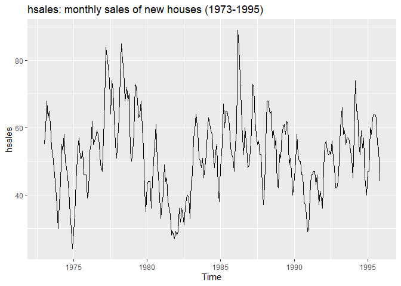

```r
mytitle <- "hsales: monthly sales of new houses (1973-1995)"
autoplot(hsales) + ggtitle(mytitle)
```

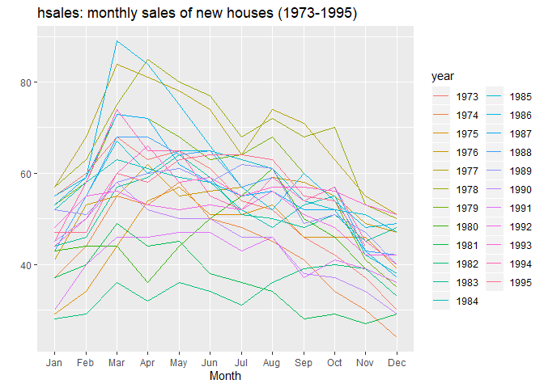

```r
ggseasonplot(hsales) + ggtitle(mytitle)
```

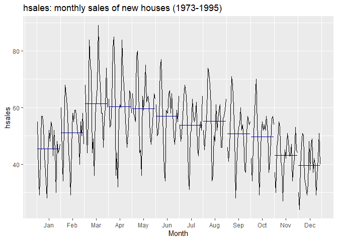

```r
ggsubseriesplot(hsales) + ggtitle(mytitle)
```

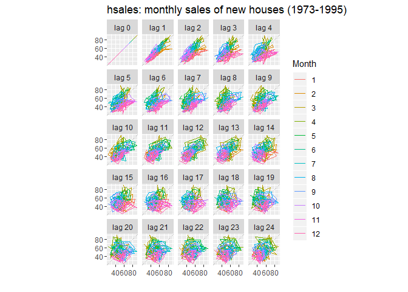

```r
gglagplot(hsales,set.lags = 0:24) + ggtitle(mytitle)
```

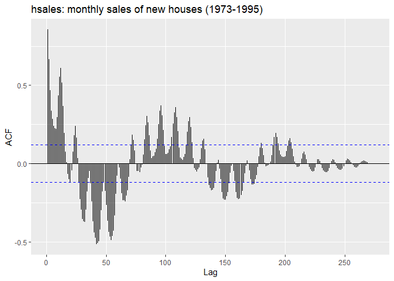

```r
ggAcf(hsales, lag.max = 275) + ggtitle(mytitle)
```

##### The plots exhibit seasonality, with highest sales in the Spring of each year (March, April, May.)

##### Cyclicality is also evident, with a cycle of about 8 years.

##### The plots do not show any long-term trend.

### 2.6b: `usdeaths` - Monthly accidental deaths in USA (1973-1978).

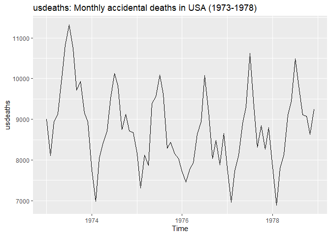

```r
mytitle <- "usdeaths: Monthly accidental deaths in USA (1973-1978)"
autoplot(usdeaths) + ggtitle(mytitle)
```

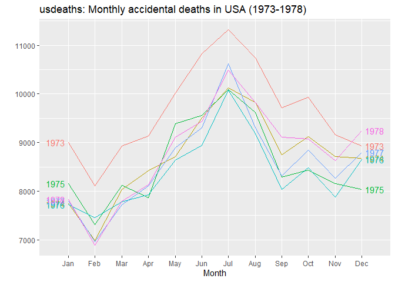

```r
ggseasonplot(usdeaths, year.labels=TRUE, year.labels.left=TRUE) + ggtitle(mytitle)
```

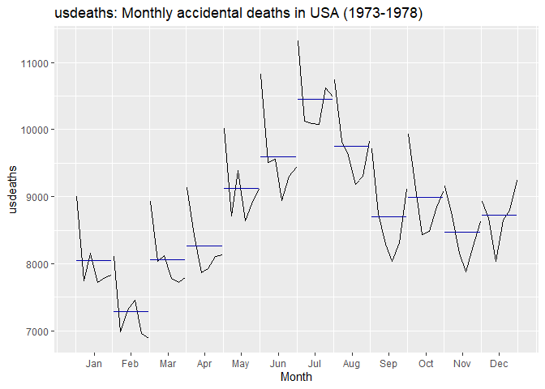

```r
ggsubseriesplot(usdeaths) + ggtitle(mytitle)
```

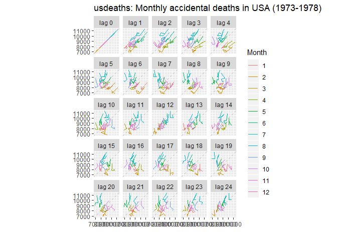

```r
gglagplot(usdeaths,set.lags = 0:24) + ggtitle(mytitle)
```

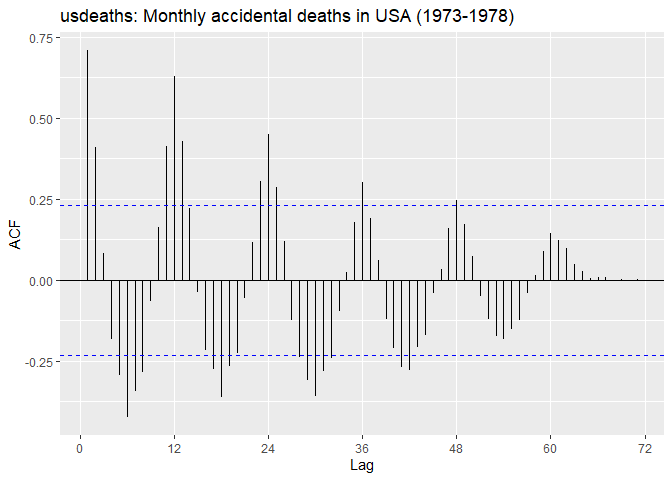

```r
ggAcf(usdeaths, lag.max = 72) + ggtitle(mytitle)
```

#### The data exhibits seasonality, with more accidental deaths occurring in the summertime (e.g., July) and fewer occuring in the winter (e.g., February.)

#### The data does not exhibit any long-term trend nor does it display cyclicality.

### 2.6c: `bricksq` - Australian quarterly clay brick production: 1956–1994.

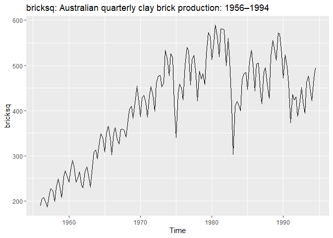

```r
mytitle <- "bricksq: Australian quarterly clay brick production: 1956–1994"
autoplot(bricksq) + ggtitle(mytitle)
```

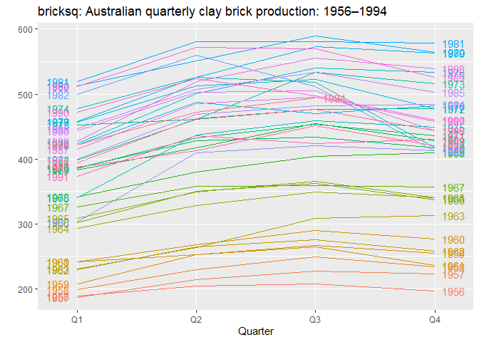

```r
ggseasonplot(bricksq, year.labels=TRUE, year.labels.left=TRUE) + ggtitle(mytitle)
```

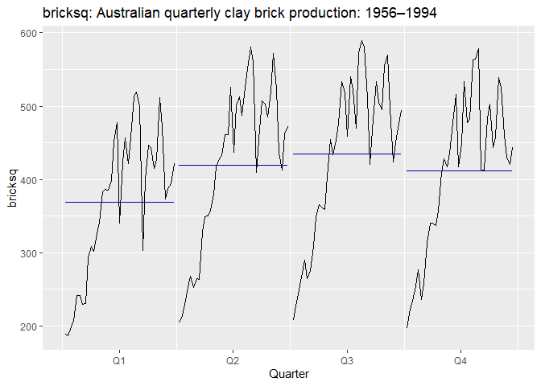

```r
ggsubseriesplot(bricksq) + ggtitle(mytitle)
```

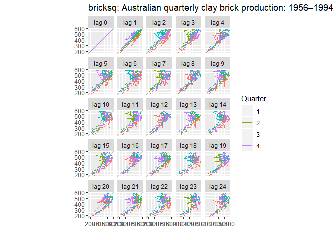

```r
gglagplot(bricksq,set.lags = 0:24) + ggtitle(mytitle)
```

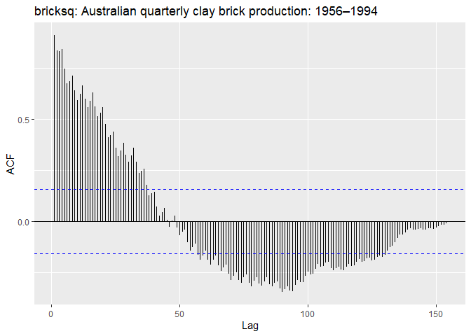

```r
ggAcf(bricksq, lag.max = 155) + ggtitle(mytitle)
```

##### Seasonality is evident with **higher** production of bricks in Q3, which includes the Australian **winter** months (July-August-September) and lower production in Q1, which includes the Australian **summer**, perhaps because of vacation holidays.

##### The data exhibits a clear upward trend from 1956-1974, after which time there is a clear “regime shift”, when the data becomes cyclical instead of trending upwards, with dips in 1975, 1983, and 1991 indicating an eight-year cycle following such change.

### 2.6d: `sunspotarea` - Annual average sunspot area (1875-2015).

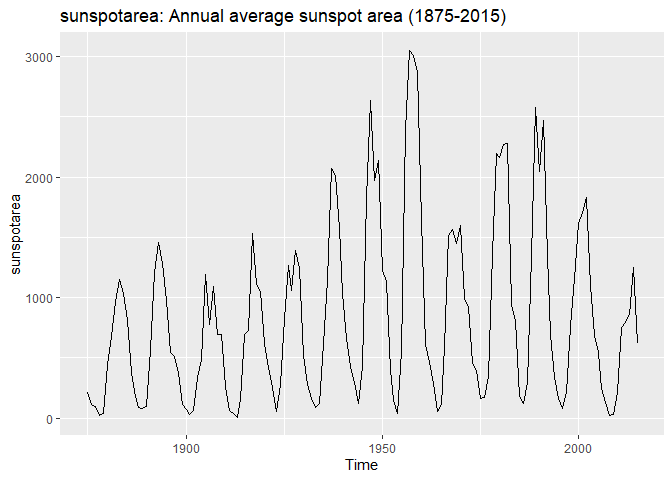

```r
mytitle <- "sunspotarea: Annual average sunspot area (1875-2015)"
autoplot(sunspotarea) + ggtitle(mytitle)
```

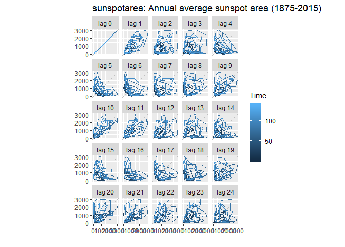

```r
##ggseasonplot(sunspotarea, year.labels=TRUE, year.labels.left=TRUE) + ggtitle(mytitle)
## Error in ggseasonplot(sunspotarea, year.labels = TRUE, year.labels.left = TRUE) :
##  Data are not seasonal

##ggsubseriesplot(sunspotarea) + ggtitle(mytitle)
## Error in ggsubseriesplot(sunspotarea) : Data are not seasonal

gglagplot(sunspotarea,set.lags = 0:24) + ggtitle(mytitle)
```

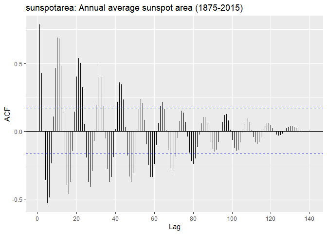

```r
ggAcf(sunspotarea, lag.max = 141) + ggtitle(mytitle)
```

##### Because the data is annual, it cannot exhibit seasonality, thus the `ggseasonplot` and `ggsubseriesplot` functions return errors.

##### The data is cyclical, with the sunspot cycle running about 11 years in duration.